# Predicting Diabetes: Exploring Decision Trees, kNN and Logistic Regression

Becky

Mar 2023

## 1. Information on dataset

This dataset was extracted from Kaggle at https://www.kaggle.com/datasets/uciml/pima-indians-diabetes-database.

*From Kaggle:*  
*“This dataset is originally from the National Institute of Diabetes and Digestive and Kidney Diseases. The objective of the dataset is to diagnostically predict whether or not a patient has diabetes, based on certain diagnostic measurements included in the dataset. Several constraints were placed on the selection of these instances from a larger database. In particular, all patients here are females at least 21 years old of Pima Indian heritage.”*

**Variables**  
– Pregnancies: No. of times pregnant – Glucose: Plasma glucose concentration 2 hours after administration of an oral glucose tolerance test (mg/dl)  
– BloodPressure: Diastolic blood pressure (mm Hg)  
– SkinThickness: Triceps skin fold thickness (mm)  
– Insulin: 2-Hour serum insulin (mu U/ml)  
– BMI: Body mass index (weight in kg/(height in m)^2)  
– DiabetesPedigreeFunction: Scores likelihood of diabetes based on family history – Age: Age in years  
– Outcome: 0 = No diabetes, 1 = Diabetes

Notes:  
* Glucose tolerance test is used to detect diabetes. Participants are administered a sugary drink. Blood is then drawn after 2 - 3 hours and tested for its sugar levels. < 140mg/dl ~ normal, > 140 mg/dl and < 199 mg/dl ~ potentially prediabetic, > 199 mg/dl ~ potentially diabetic. Further testing is required for diagnosis.  
* Individual who produce insulin but are resistant to its effects have type 2 diabetes. Type 2 diabetes is reversible if detected early.

```r
# Load libraries
library(tidyverse)
library(ggplot2)
library(visdat)
library(psych)
library(naniar)
library(VIM)
library(mice)
library(ggcorrplot)
library(rpart)
library(caret)
library(RANN)
library(rpart.plot)
library(randomForest)
library(class)
library(ROCR)
library(car)
library(GGally)
```

## 2. Understanding the data

```r
diabetes <- read.csv("data/diabetes.csv")
str(diabetes)
```

```
## 'data.frame':    768 obs. of  9 variables:
##  $ Pregnancies             : int  6 1 8 1 0 5 3 10 2 8 ...
##  $ Glucose                 : int  148 85 183 89 137 116 78 115 197 125 ...
##  $ BloodPressure           : int  72 66 64 66 40 74 50 0 70 96 ...
##  $ SkinThickness           : int  35 29 0 23 35 0 32 0 45 0 ...
##  $ Insulin                 : int  0 0 0 94 168 0 88 0 543 0 ...
##  $ BMI                     : num  33.6 26.6 23.3 28.1 43.1 25.6 31 35.3 30.5 0 ...
##  $ DiabetesPedigreeFunction: num  0.627 0.351 0.672 0.167 2.288 ...
##  $ Age                     : int  50 31 32 21 33 30 26 29 53 54 ...
##  $ Outcome                 : int  1 0 1 0 1 0 1 0 1 1 ...
```

```r
# Convert response to factor
diabetes$Outcome <- as.factor(diabetes$Outcome)
summary(diabetes)
```

```
##   Pregnancies        Glucose      BloodPressure    SkinThickness
##  Min.   : 0.000   Min.   :  0.0   Min.   :  0.00   Min.   : 0.00
##  1st Qu.: 1.000   1st Qu.: 99.0   1st Qu.: 62.00   1st Qu.: 0.00
##  Median : 3.000   Median :117.0   Median : 72.00   Median :23.00
##  Mean   : 3.845   Mean   :120.9   Mean   : 69.11   Mean   :20.54
##  3rd Qu.: 6.000   3rd Qu.:140.2   3rd Qu.: 80.00   3rd Qu.:32.00
##  Max.   :17.000   Max.   :199.0   Max.   :122.00   Max.   :99.00
##     Insulin           BMI        DiabetesPedigreeFunction      Age
##  Min.   :  0.0   Min.   : 0.00   Min.   :0.0780           Min.   :21.00
##  1st Qu.:  0.0   1st Qu.:27.30   1st Qu.:0.2437           1st Qu.:24.00
##  Median : 30.5   Median :32.00   Median :0.3725           Median :29.00
##  Mean   : 79.8   Mean   :31.99   Mean   :0.4719           Mean   :33.24
##  3rd Qu.:127.2   3rd Qu.:36.60   3rd Qu.:0.6262           3rd Qu.:41.00
##  Max.   :846.0   Max.   :67.10   Max.   :2.4200           Max.   :81.00
##  Outcome
##  0:500
##  1:268
##
##
##
##
```

There are 9 variables with 768 observations. Glucose, BloodPressure, SkinThickness, Insulin and BMI have 0 values, which is not plausible for its range of measurement. 500 individuals are labeled as non diabetic and 268 are labeled as diabetic.

### 2.1 Missing and/or duplicated rows

```r
sum(is.na(diabetes))
```

```
## [1] 0
```

```r
diabetes[is.na(diabetes), ]
```

```
## [1] Pregnancies              Glucose                  BloodPressure
## [4] SkinThickness            Insulin                  BMI
## [7] DiabetesPedigreeFunction Age                      Outcome
## <0 rows> (or 0-length row.names)
```

```r
nrow(diabetes) == nrow(distinct(diabetes))
```

```
## [1] TRUE
```

Raw data does not have NA cells or duplicated rows.

### 2.2 Variable check

As Glucose, BloodPressure, SkinThickness, Insulin and BMI have 0 values, we will treat them as missing observations.

```r
diabetes_NA <- diabetes %>%
  mutate_at(c(2:6), ~na_if(.,0))
summary(diabetes_NA)
```

```
##   Pregnancies        Glucose      BloodPressure    SkinThickness
##  Min.   : 0.000   Min.   : 44.0   Min.   : 24.00   Min.   : 7.00
##  1st Qu.: 1.000   1st Qu.: 99.0   1st Qu.: 64.00   1st Qu.:22.00
##  Median : 3.000   Median :117.0   Median : 72.00   Median :29.00
##  Mean   : 3.845   Mean   :121.7   Mean   : 72.41   Mean   :29.15
##  3rd Qu.: 6.000   3rd Qu.:141.0   3rd Qu.: 80.00   3rd Qu.:36.00
##  Max.   :17.000   Max.   :199.0   Max.   :122.00   Max.   :99.00
##                   NA's   :5       NA's   :35       NA's   :227
##     Insulin            BMI        DiabetesPedigreeFunction      Age
##  Min.   : 14.00   Min.   :18.20   Min.   :0.0780           Min.   :21.00
##  1st Qu.: 76.25   1st Qu.:27.50   1st Qu.:0.2437           1st Qu.:24.00
##  Median :125.00   Median :32.30   Median :0.3725           Median :29.00
##  Mean   :155.55   Mean   :32.46   Mean   :0.4719           Mean   :33.24
##  3rd Qu.:190.00   3rd Qu.:36.60   3rd Qu.:0.6262           3rd Qu.:41.00
##  Max.   :846.00   Max.   :67.10   Max.   :2.4200           Max.   :81.00
##  NA's   :374      NA's   :11
##  Outcome
##  0:500
##  1:268
##
##
##
##
##
```

5 observations for Glucose, 35 observations for BloodPressure, 227 observations for SkinThickness, 374 observations for Insulin and 11 observations for BMI are missing. We can choose to:  
1. Drop rows with missing observations  
2. Impute missing observations  
Dropping rows with missing observations would result in a substantial (~50%) loss of sample size. Smaller sample sizes have increased uncertainty and might reduce the effectiveness of subsequent analysis or modeling. As such, let’s explore the option to impute missing data.  
There are 3 types of missing:  
1. Missing completely at random (MCAR)  
2. Missing at random (MNAR)  
3. Missing not at random (MNAR)  
To consider the type of imputation, we shall try to identify if there is a pattern to its missingness.

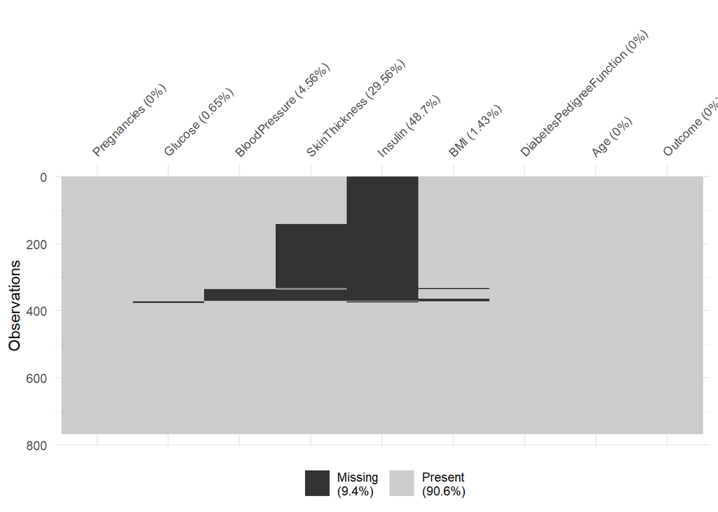

```r
vis_miss(diabetes_NA, cluster = TRUE)
```

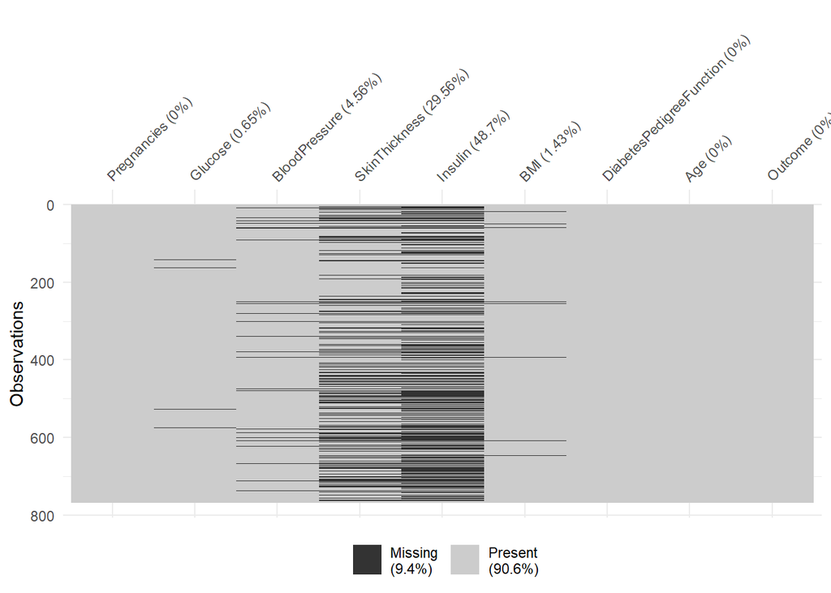

```r
# Check if missing data is based on other variables in dataset
Miss_pattern <- function(variable) {
  diabetes_NA %>%
  arrange({{variable}}) %>%
  vis_miss()
}

Miss_pattern(Pregnancies)
```

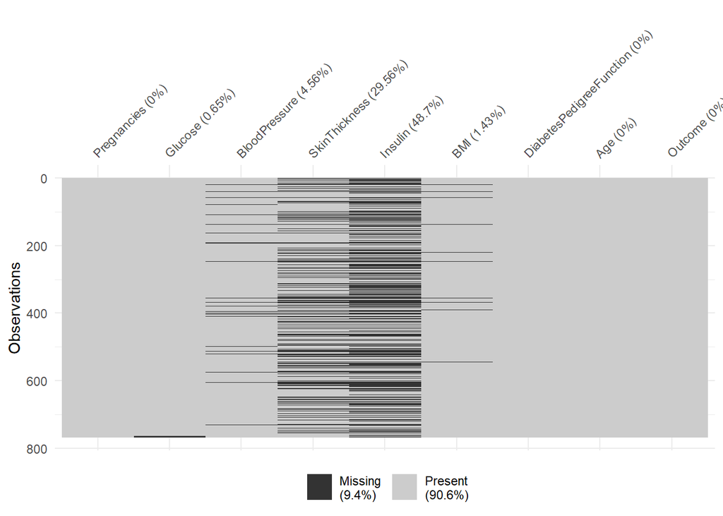

```r
Miss_pattern(Glucose)
```

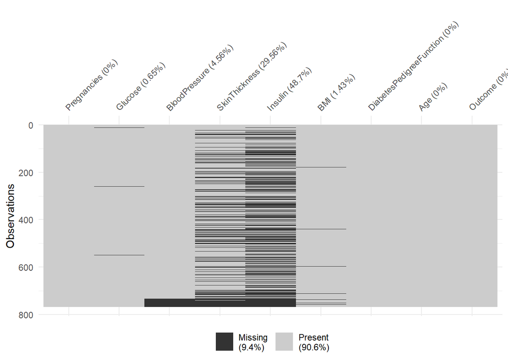

```r
Miss_pattern(BloodPressure)
```

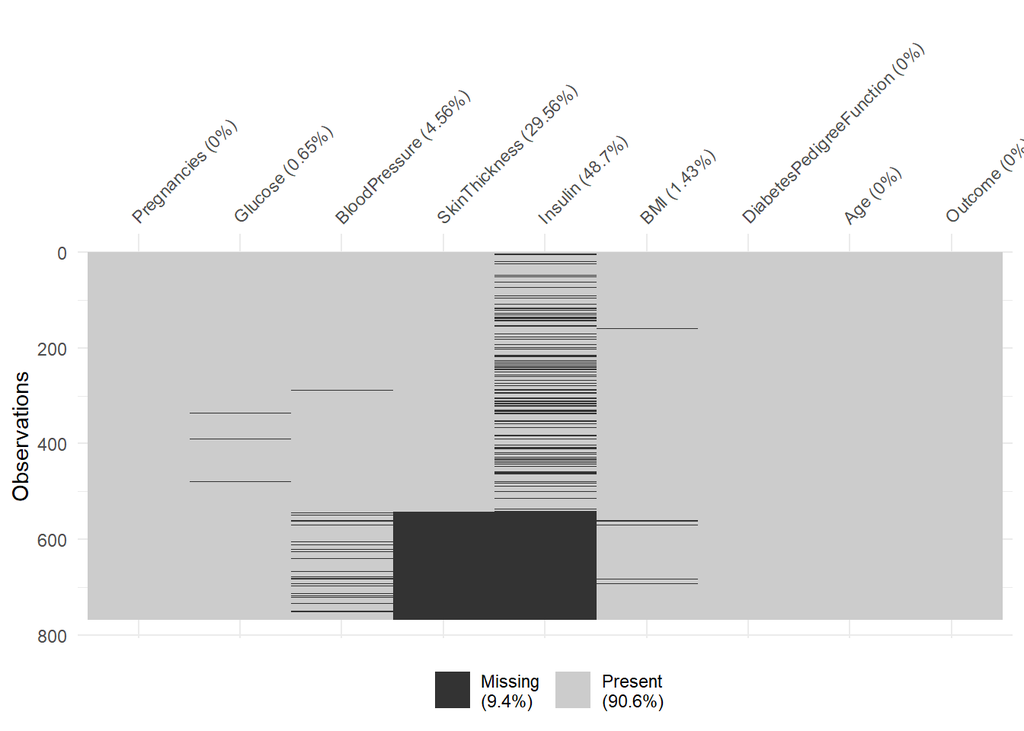

```r
Miss_pattern(SkinThickness)
```

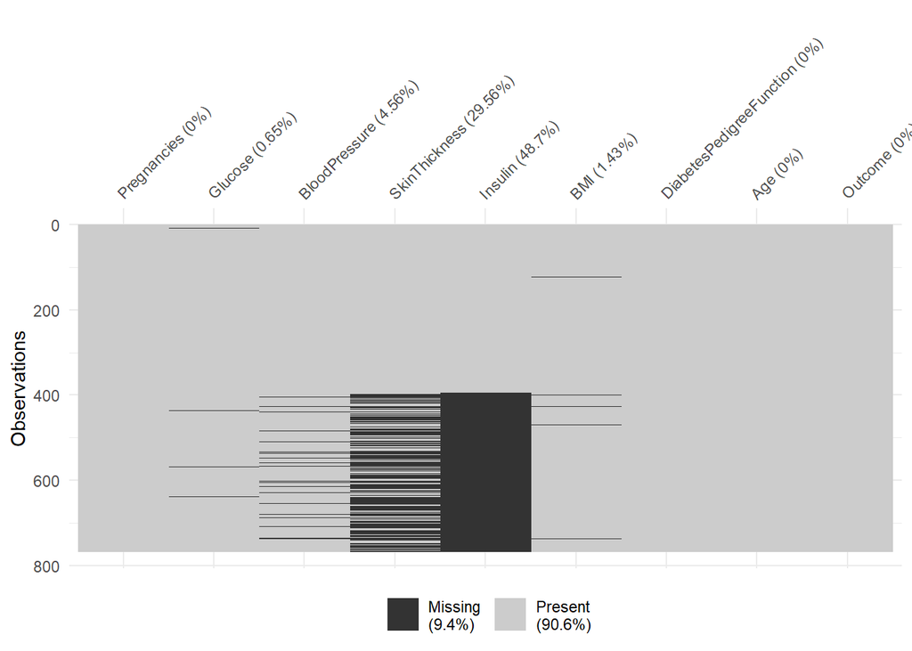

```r
Miss_pattern(Insulin)
```

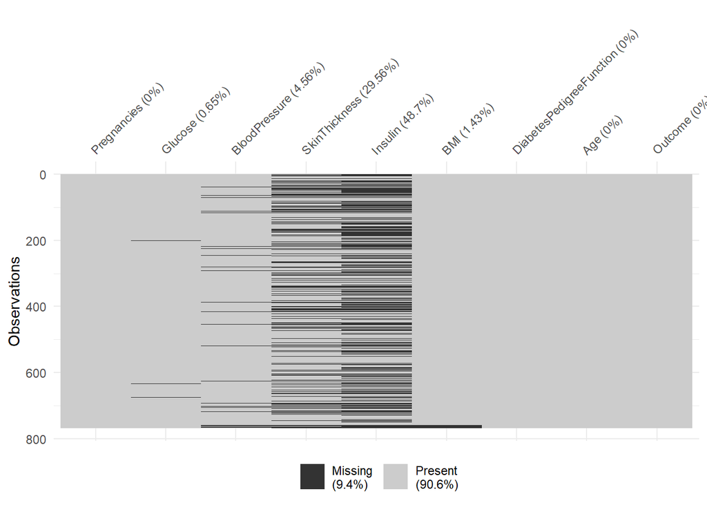

```r
Miss_pattern(BMI)
```

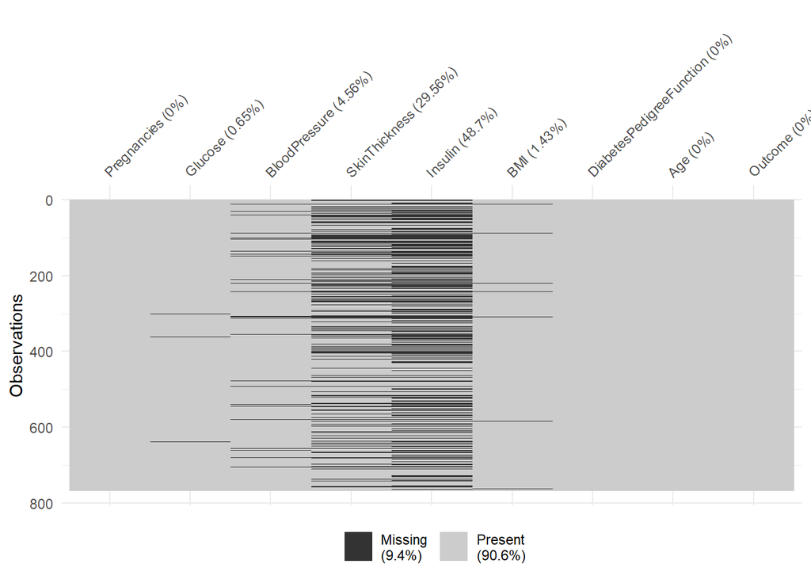

```r
Miss_pattern(DiabetesPedigreeFunction)
```

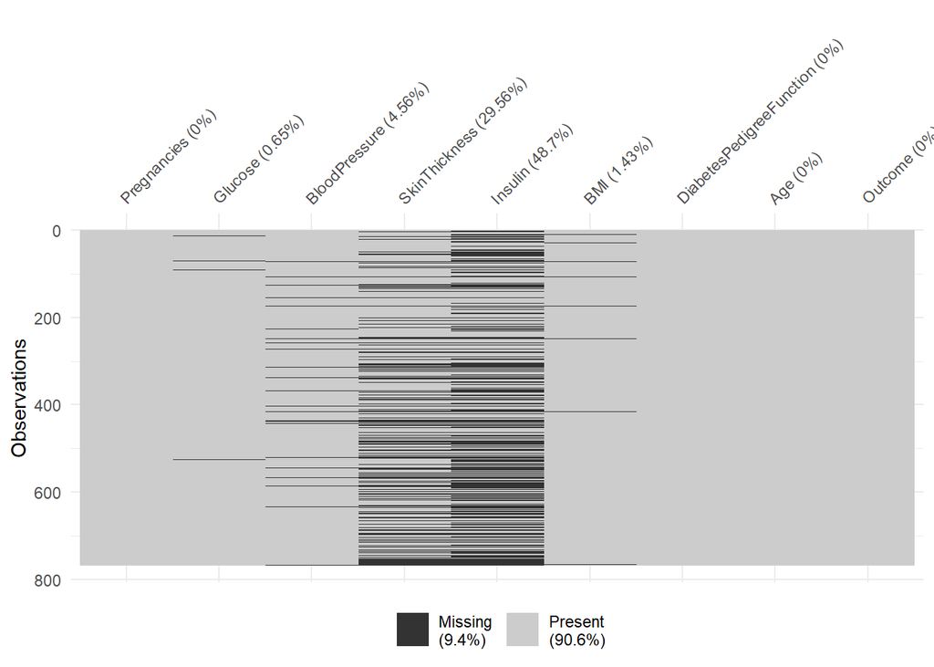

```r
Miss_pattern(Age)
```

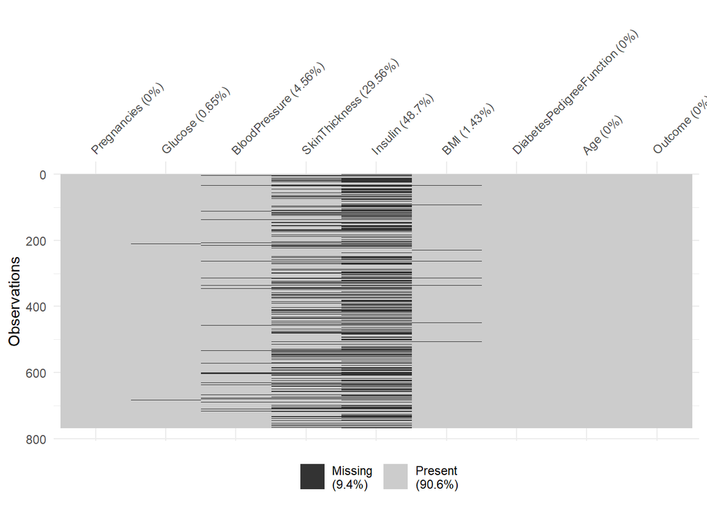

```r
Miss_pattern(Outcome)
```

### 2.3 Overview of distribution

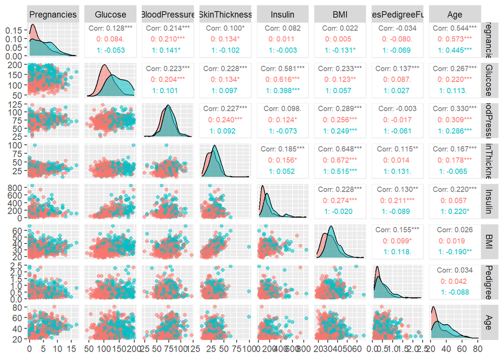

```r
ggpairs(diabetes_NA,
        columns = 1:8,
        aes(color = Outcome, alpha = 0.4),
        upper = list(continuous = wrap("cor", size = 2.5)))
```

Overall, variables are mildly to moderately correlated with each other. Insulin in particular, shows a moderate correlation with Glucose at 0.581. SkinThickness also shows a moderate correlation with BMI at 0.648. As slight clustering patterns can be observed for aformentioned variables, we will attempt to impute missing observations with kNN.

### 2.3 kNN Imputation

```r
# Automatically standardises data
imp <- preProcess(diabetes_NA,
                  method = "knnImpute",
                  k = 27,
                  knnSummary = mean)
diabetes_imp <- predict(imp, diabetes_NA)
summary(diabetes_imp)
```

```
##   Pregnancies         Glucose           BloodPressure      SkinThickness
##  Min.   :-1.1411   Min.   :-2.5441340   Min.   :-3.90927   Min.   :-2.11449
##  1st Qu.:-0.8443   1st Qu.:-0.7183986   1st Qu.:-0.67881   1st Qu.:-0.58733
##  Median :-0.2508   Median :-0.1534850   Median :-0.03272   Median :-0.01464
##  Mean   : 0.0000   Mean   :-0.0009535   Mean   :-0.01018   Mean   :-0.01640
##  3rd Qu.: 0.6395   3rd Qu.: 0.6079203   3rd Qu.: 0.61337   3rd Qu.: 0.46259
##  Max.   : 3.9040   Max.   : 2.5319016   Max.   : 4.00535   Max.   : 6.66667
##     Insulin              BMI            DiabetesPedigreeFunction
##  Min.   :-1.19173   Min.   :-2.058843   Min.   :-1.1888
##  1st Qu.:-0.51063   1st Qu.:-0.715880   1st Qu.:-0.6885
##  Median :-0.15616   Median :-0.051887   Median :-0.2999
##  Mean   :-0.01763   Mean   :-0.003446   Mean   : 0.0000
##  3rd Qu.: 0.26948   3rd Qu.: 0.598201   3rd Qu.: 0.4659
##  Max.   : 5.81306   Max.   : 5.002541   Max.   : 5.8797
##       Age          Outcome
##  Min.   :-1.0409   0:500
##  1st Qu.:-0.7858   1:268
##  Median :-0.3606
##  Mean   : 0.0000
##  3rd Qu.: 0.6598
##  Max.   : 4.0611
```

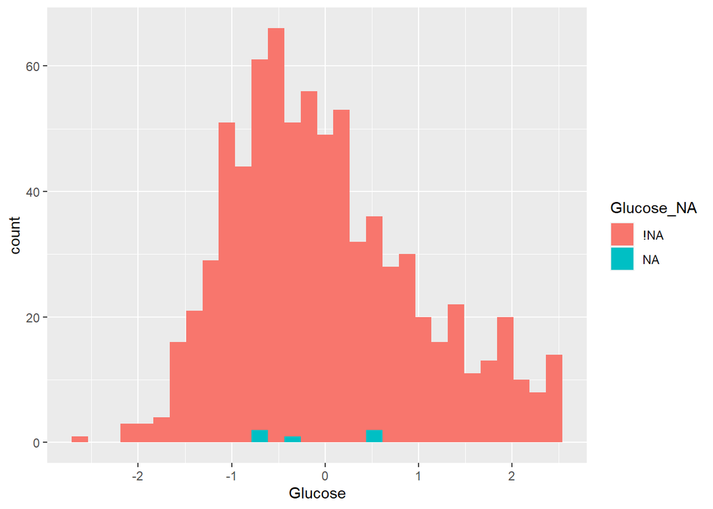

```r
# Visualise distribution of imputed data vs actual data
shadow <- diabetes_NA %>%
  bind_shadow(only_miss = TRUE) %>%
  select(10:14)

imp_shadow <- cbind(diabetes_imp, shadow)

Distri_imp <- function(x, fill) {
  ggplot(imp_shadow, aes({{x}}, fill = {{fill}})) +
    geom_histogram()
}

Distri_imp(Glucose, Glucose_NA)
```

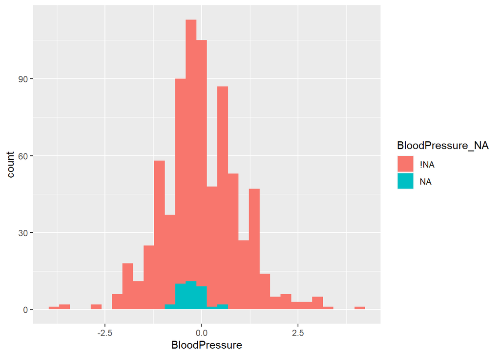

```r
Distri_imp(BloodPressure, BloodPressure_NA)
```

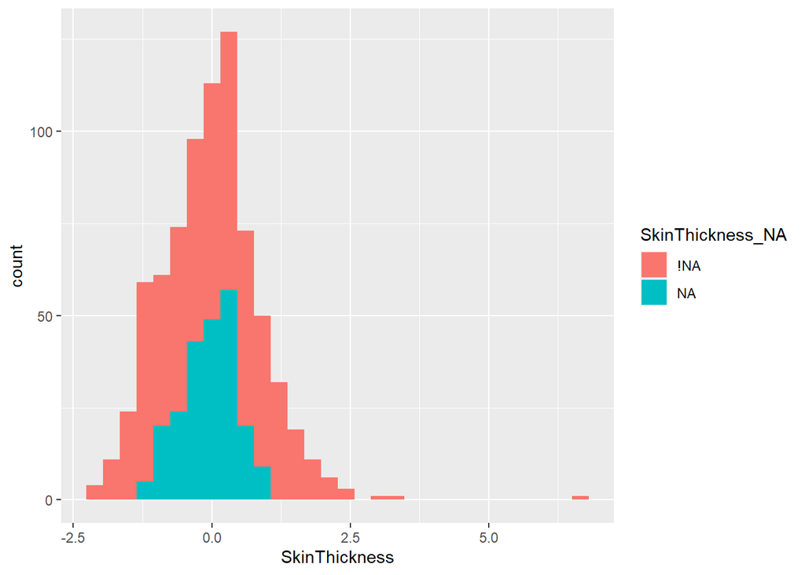

```r
Distri_imp(SkinThickness, SkinThickness_NA)
```

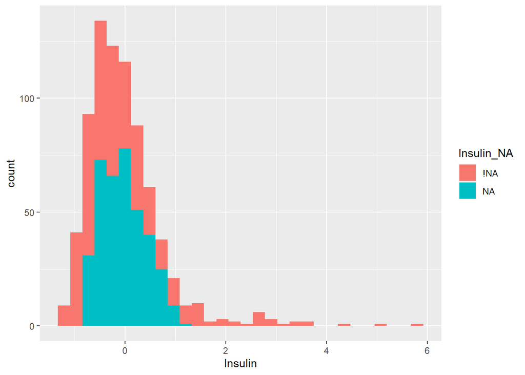

```r
Distri_imp(Insulin, Insulin_NA)
```

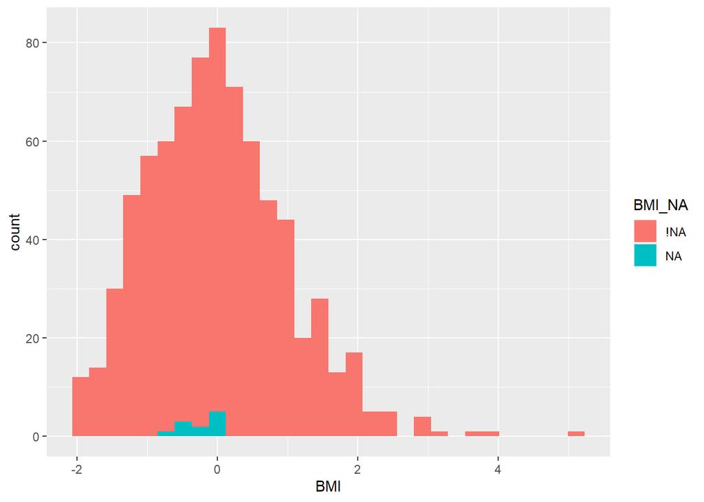

```r
Distri_imp(BMI, BMI_NA)
```

Data imputed with kNN has a distribution that mirrors that of actual data.

## 3. Create train and test sets

We will partition the data into 70:30 train test split for both imputed and non imputed datasets. The non imputed data will be used to train the model for decision trees as its algorithim is able to handle missing values.

```r
# Imputed
set.seed(500)
index <- sample(1:nrow(diabetes_imp), nrow(diabetes_imp) * .7, replace = FALSE)
train.imp <- diabetes_imp[index,]
test.imp <- diabetes_imp[-index,]

# Original
set.seed(500)
index <- sample(1:nrow(diabetes_NA), nrow(diabetes_NA) * .7, replace = FALSE)
train.org <- diabetes_NA[index,]
test.org <- diabetes_NA[-index,]
```

## 4. Decision Tree

### 4.1 Modeling

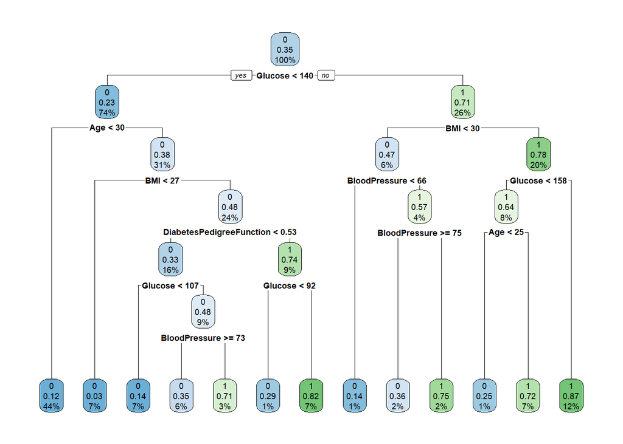

```r
set.seed(500)
mdl.dt <- rpart(Outcome ~., data = train.org, method = "class")
rpart.plot(mdl.dt)
```

```r
printcp(mdl.dt)
```

```
##
## Classification tree:
## rpart(formula = Outcome ~ ., data = train.org, method = "class")
##
## Variables actually used in tree construction:
## [1] Age                      BloodPressure            BMI
## [4] DiabetesPedigreeFunction Glucose
##
## Root node error: 189/537 = 0.35196
##
## n= 537
##
##         CP nsplit rel error  xerror     xstd
## 1 0.301587      0   1.00000 1.00000 0.058556
## 2 0.038801      1   0.69841 0.73016 0.053577
## 3 0.018519      4   0.58201 0.72487 0.053449
## 4 0.015873      6   0.54497 0.70370 0.052926
## 5 0.014109      7   0.52910 0.71958 0.053320
## 6 0.010582     10   0.48677 0.70370 0.052926
## 7 0.010000     12   0.46561 0.72487 0.053449
```

The number of splits for mdl.dt is 12, with the lowest complexity parameter (cp) of 0.01.

### 4.2 Prediction

```r
mdl.dt.pred <- predict(mdl.dt, test.org, type = "class")
confusionMatrix(mdl.dt.pred, test.org$Outcome, positive = "1")
```

```
## Confusion Matrix and Statistics
##
##           Reference
## Prediction   0   1
##          0 123  31
##          1  29  48
##
##                Accuracy : 0.7403
##                  95% CI : (0.6787, 0.7956)
##     No Information Rate : 0.658
##     P-Value [Acc > NIR] : 0.004463
##
##                   Kappa : 0.4194
##
##  Mcnemar's Test P-Value : 0.897279
##
##             Sensitivity : 0.6076
##             Specificity : 0.8092
##          Pos Pred Value : 0.6234
##          Neg Pred Value : 0.7987
##              Prevalence : 0.3420
##          Detection Rate : 0.2078
##    Detection Prevalence : 0.3333
##       Balanced Accuracy : 0.7084
##
##        'Positive' Class : 1
##
```

To ensure that diabetes can be detected for early intervention, and to reduce unnecessary healthcare cost incurred from false diagnosis, we look to minimise false negatives and false positives. Accuracy (TP+TN/all), sensitivity (TP/(TP+FN)) and specificity (TN/(TN+FP)) will be compared between models.

mdl.dt returned an accuracy of 0.7403, sensitivity of 0.6076, specificity of 0.8092 with a kappa of 0.4194 (moderate agreement).

### 4.3 Pruning

```r
printcp(mdl.dt)
```

```
##
## Classification tree:
## rpart(formula = Outcome ~ ., data = train.org, method = "class")
##
## Variables actually used in tree construction:
## [1] Age                      BloodPressure            BMI
## [4] DiabetesPedigreeFunction Glucose
##
## Root node error: 189/537 = 0.35196
##
## n= 537
##
##         CP nsplit rel error  xerror     xstd
## 1 0.301587      0   1.00000 1.00000 0.058556
## 2 0.038801      1   0.69841 0.73016 0.053577
## 3 0.018519      4   0.58201 0.72487 0.053449
## 4 0.015873      6   0.54497 0.70370 0.052926
## 5 0.014109      7   0.52910 0.71958 0.053320
## 6 0.010582     10   0.48677 0.70370 0.052926
## 7 0.010000     12   0.46561 0.72487 0.053449
```

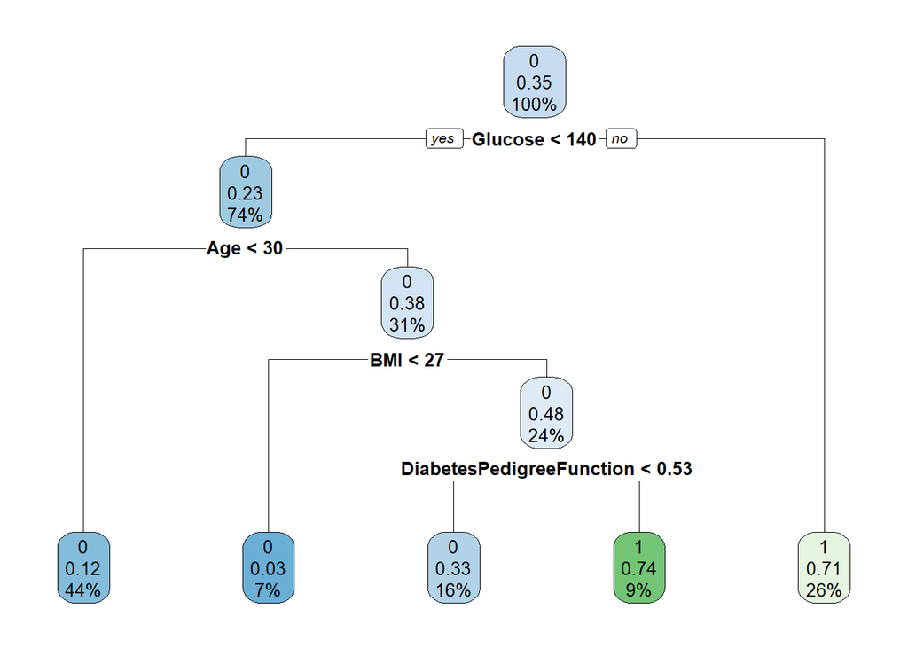

```r
set.seed(500)
mdl.dt.tuned <- rpart(Outcome~.,
                    data = train.org,
                    method = "class",
                    control = rpart.control(cp = 0.027, minsplit = 3))

rpart.plot(mdl.dt.tuned)
```

### 4.4 Evaluation

```r
mdl.dt.tuned.pred <- predict(mdl.dt.tuned, test.org, type = "class")
mdl.dt.tuned.cf <- confusionMatrix(mdl.dt.tuned.pred, test.org$Outcome, positive = "1")
mdl.dt.tuned.cf
```

```
## Confusion Matrix and Statistics
##
##           Reference
## Prediction   0   1
##          0 119  34
##          1  33  45
##
##                Accuracy : 0.71
##                  95% CI : (0.6468, 0.7676)
##     No Information Rate : 0.658
##     P-Value [Acc > NIR] : 0.05395
##
##                   Kappa : 0.3536
##
##  Mcnemar's Test P-Value : 1.00000
##
##             Sensitivity : 0.5696
##             Specificity : 0.7829
##          Pos Pred Value : 0.5769
##          Neg Pred Value : 0.7778
##              Prevalence : 0.3420
##          Detection Rate : 0.1948
##    Detection Prevalence : 0.3377
##       Balanced Accuracy : 0.6763
##
##        'Positive' Class : 1
##
```

mdl.dt.tuned did not perform as well on unseen data as mdl.dt. It returned a lower accuracy of 0.71, sensitivity of 0.5696, specificity of 0.7829 with a kappa of 0.3536 (fair agreement).

## 5. Random Forest

### 5.1 Modeling

```r
set.seed(500)
mdl.rf <- randomForest(Outcome~., data = train.imp) #as randomForest is unable to handle missing data, imp version will be used
mdl.rf
```

```
##
## Call:
##  randomForest(formula = Outcome ~ ., data = train.imp)
##                Type of random forest: classification
##                      Number of trees: 500
## No. of variables tried at each split: 2
##
##         OOB estimate of  error rate: 25.33%
## Confusion matrix:
##     0   1 class.error
## 0 296  52   0.1494253
## 1  84 105   0.4444444
```

### 5.2 Prediction

```r
mdl.rf.pred <- predict(mdl.rf, test.imp, type = "class")
confusionMatrix(mdl.rf.pred, test.imp$Outcome, positive = "1")
```

```
## Confusion Matrix and Statistics
##
##           Reference
## Prediction   0   1
##          0 129  29
##          1  23  50
##
##                Accuracy : 0.7749
##                  95% CI : (0.7155, 0.8271)
##     No Information Rate : 0.658
##     P-Value [Acc > NIR] : 7.4e-05
##
##                   Kappa : 0.4905
##
##  Mcnemar's Test P-Value : 0.4881
##
##             Sensitivity : 0.6329
##             Specificity : 0.8487
##          Pos Pred Value : 0.6849
##          Neg Pred Value : 0.8165
##              Prevalence : 0.3420
##          Detection Rate : 0.2165
##    Detection Prevalence : 0.3160
##       Balanced Accuracy : 0.7408
##
##        'Positive' Class : 1
##
```

mdl.rf returned an accuracy of 0.7749, sensitivity of 0.6329, specificity of 0.8487 with a kappa of 0.4905.

### 5.2 Tuning

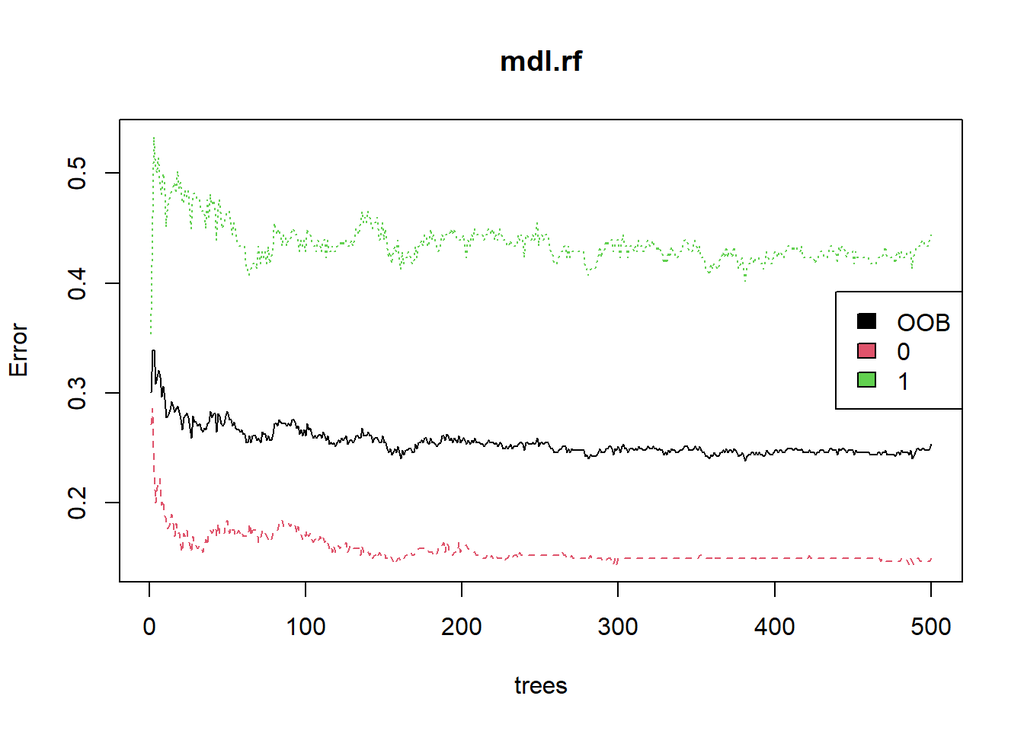

```r
plot(mdl.rf)
legend(x = "right", legend = colnames(mdl.rf$err.rate),fill = 1:ncol(mdl.rf$err.rate))
```

```
## mtry = 2  OOB error = 25.33%
## Searching left ...
## mtry = 1     OOB error = 24.77%
## 0.02205882 0.05
## Searching right ...
## mtry = 8     OOB error = 24.95%
## 0.01470588 0.05
```

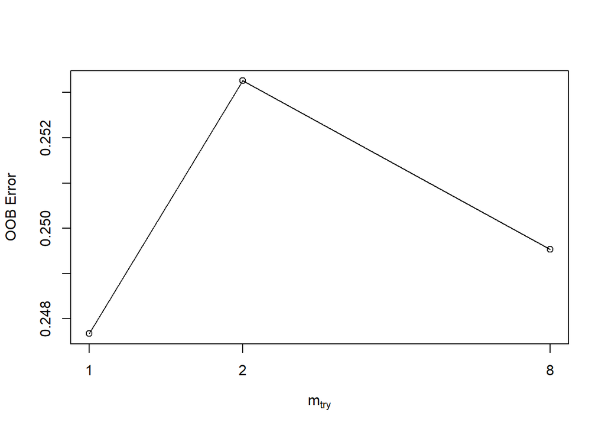

```r
set.seed(500)
mdl.rf.mtry <- tuneRF(train.imp[,-9], train.imp[,9],
                       stepFactor = 8,
                       plot = TRUE,
                       ntreeTry = 500,
                       trace = TRUE,
                       improve = 0.05
                       )
```

mtry = 1 returned the lowest OOB error.

```r
set.seed(500)
mdl.rf.tuned <- randomForest(Outcome~., data = train.imp, ntree = 500, mtry = 1)
mdl.rf.tuned
```

```
##
## Call:
##  randomForest(formula = Outcome ~ ., data = train.imp, ntree = 500,      mtry = 1)
##                Type of random forest: classification
##                      Number of trees: 500
## No. of variables tried at each split: 1
##
##         OOB estimate of  error rate: 24.39%
## Confusion matrix:
##     0   1 class.error
## 0 300  48   0.1379310
## 1  83 106   0.4391534
```

### 5.3 Evaluation

```r
mdl.rf.tuned.pred <- predict(mdl.rf.tuned, test.imp, type = "class")
mdl.rf.tuned.cf <- confusionMatrix(mdl.rf.tuned.pred, test.imp$Outcome, positive = "1")
mdl.rf.tuned.cf
```

```
## Confusion Matrix and Statistics
##
##           Reference
## Prediction   0   1
##          0 129  27
##          1  23  52
##
##                Accuracy : 0.7835
##                  95% CI : (0.7248, 0.8349)
##     No Information Rate : 0.658
##     P-Value [Acc > NIR] : 2.112e-05
##
##                   Kappa : 0.5132
##
##  Mcnemar's Test P-Value : 0.6714
##
##             Sensitivity : 0.6582
##             Specificity : 0.8487
##          Pos Pred Value : 0.6933
##          Neg Pred Value : 0.8269
##              Prevalence : 0.3420
##          Detection Rate : 0.2251
##    Detection Prevalence : 0.3247
##       Balanced Accuracy : 0.7535
##
##        'Positive' Class : 1
##
```

mdl.rf.tuned returned a slightly higher accuracy of 0.7835, sensitivity of 0.6582, specificity of 0.8487 with a kappa of 0.5132.

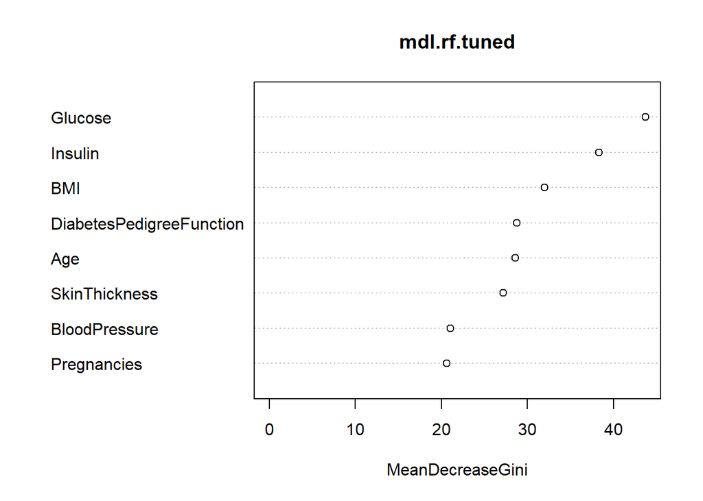

```r
varImpPlot(mdl.rf.tuned)
```

```r
importance(mdl.rf.tuned)
```

```
##                          MeanDecreaseGini
## Pregnancies                      20.62032
## Glucose                          43.73310
## BloodPressure                    21.03820
## SkinThickness                    27.20624
## Insulin                          38.32548
## BMI                              31.99208
## DiabetesPedigreeFunction         28.78264
## Age                              28.56152
```

Variables Glucose and Insulin have the highest impact on the Random Forest model.

## 6. kNN

### 6.1 Train and test sets

```r
train.imp.knn <- train.imp[,-9]
test.imp.knn <- test.imp[,-9]

train.imp.label <- train.imp[,9]
test.imp.label <- test.imp[,9]
```

### 6.2 Applying kNN algorithm

```r
mdl.knn <- knn(train = train.imp.knn,
               test = test.imp.knn,
               cl = train.imp.label,
               k = 23) #sqrt(nrow(train.imp.knn))
```

```r
mdl.knn.cf <- confusionMatrix(table("Prediction" = mdl.knn, "Actual" = test.imp.label ), positive = "1")
mdl.knn.cf
```

```
## Confusion Matrix and Statistics
##
##           Actual
## Prediction   0   1
##          0 132  39
##          1  20  40
##
##                Accuracy : 0.7446
##                  95% CI : (0.6833, 0.7995)
##     No Information Rate : 0.658
##     P-Value [Acc > NIR] : 0.002885
##
##                   Kappa : 0.3977
##
##  Mcnemar's Test P-Value : 0.019109
##
##             Sensitivity : 0.5063
##             Specificity : 0.8684
##          Pos Pred Value : 0.6667
##          Neg Pred Value : 0.7719
##              Prevalence : 0.3420
##          Detection Rate : 0.1732
##    Detection Prevalence : 0.2597
##       Balanced Accuracy : 0.6874
##
##        'Positive' Class : 1
##
```

mdl.knn returned an accuracy of 0.7446, sensitivity of 0.5063, specificity of 0.8684 with a kappa of 0.3977.

### 6.3 Identifying optimal k

```r
set.seed(500)
mdl.cv.knn <- train(Outcome ~ ., train.imp,
               method = "knn",
               trControl = trainControl(method = "cv", number = 10),
               tuneLength = 10)

mdl.cv.knn
```

```
## k-Nearest Neighbors
##
## 537 samples
##   8 predictor
##   2 classes: '0', '1'
##
## No pre-processing
## Resampling: Cross-Validated (10 fold)
## Summary of sample sizes: 483, 484, 483, 484, 483, 484, ...
## Resampling results across tuning parameters:
##
##   k   Accuracy   Kappa
##    5  0.7468903  0.4351224
##    7  0.7505241  0.4365276
##    9  0.7691824  0.4752066
##   11  0.7636618  0.4558614
##   13  0.7506639  0.4249455
##   15  0.7598882  0.4509825
##   17  0.7617750  0.4505596
##   19  0.7562194  0.4352014
##   21  0.7468553  0.4141442
##   23  0.7561845  0.4341043
##
## Accuracy was used to select the optimal model using the largest value.
## The final value used for the model was k = 9.
```

### 6.2 Evaluation

```r
mdl.knn.tuned <- knn(train = train.imp.knn,
               test = test.imp.knn,
               cl = train.imp.label,
               k = 9)

mdl.knn.tuned.cf <- confusionMatrix(table("Prediction" = mdl.knn.tuned, "Actual" = test.imp.label ), positive = "1")
mdl.knn.tuned.cf
```

```
## Confusion Matrix and Statistics
##
##           Actual
## Prediction   0   1
##          0 126  32
##          1  26  47
##
##                Accuracy : 0.7489
##                  95% CI : (0.6878, 0.8035)
##     No Information Rate : 0.658
##     P-Value [Acc > NIR] : 0.001826
##
##                   Kappa : 0.4318
##
##  Mcnemar's Test P-Value : 0.511482
##
##             Sensitivity : 0.5949
##             Specificity : 0.8289
##          Pos Pred Value : 0.6438
##          Neg Pred Value : 0.7975
##              Prevalence : 0.3420
##          Detection Rate : 0.2035
##    Detection Prevalence : 0.3160
##       Balanced Accuracy : 0.7119
##
##        'Positive' Class : 1
##
```

mdl.knn.tuned performed slightly better than mdl.knn. It returned an accuracy of 0.7489, sensitivity of 0.5949, specificity of 0.8289 with a kappa of 0.4318.

## 7. Logistic Regression

### 7.1 Modeling

```r
mdl.glm <- glm(Outcome~., family  = "binomial", data = train.imp)
summary(mdl.glm)
```

```
##
## Call:
## glm(formula = Outcome ~ ., family = "binomial", data = train.imp)
##
## Deviance Residuals:
##     Min       1Q   Median       3Q      Max
## -2.7066  -0.7086  -0.3958   0.6886   2.2734
##
## Coefficients:
##                          Estimate Std. Error z value Pr(>|z|)
## (Intercept)              -0.86256    0.11672  -7.390 1.47e-13 ***
## Pregnancies               0.39140    0.12982   3.015 0.002570 **
## Glucose                   1.14454    0.15184   7.538 4.77e-14 ***
## BloodPressure            -0.14456    0.12263  -1.179 0.238466
## SkinThickness             0.13616    0.17697   0.769 0.441652
## Insulin                  -0.02006    0.17004  -0.118 0.906108
## BMI                       0.57148    0.16684   3.425 0.000614 ***
## DiabetesPedigreeFunction  0.42045    0.11858   3.546 0.000391 ***
## Age                       0.17563    0.13036   1.347 0.177879
## ---
## Signif. codes:  0 '***' 0.001 '**' 0.01 '*' 0.05 '.' 0.1 ' ' 1
##
## (Dispersion parameter for binomial family taken to be 1)
##
##     Null deviance: 696.65  on 536  degrees of freedom
## Residual deviance: 494.72  on 528  degrees of freedom
## AIC: 512.72
##
## Number of Fisher Scoring iterations: 5
```

### 7.2 Feature Selection

```r
# Stepwise Regression
step(mdl.glm, direction = "back")
```

```
## Start:  AIC=512.72
## Outcome ~ Pregnancies + Glucose + BloodPressure + SkinThickness +
##     Insulin + BMI + DiabetesPedigreeFunction + Age
##
##                            Df Deviance    AIC
## - Insulin                   1   494.74 510.74
## - SkinThickness             1   495.32 511.32
## - BloodPressure             1   496.11 512.11
## - Age                       1   496.53 512.53
## <none>                          494.72 512.72
## - Pregnancies               1   504.14 520.14
## - BMI                       1   506.82 522.82
## - DiabetesPedigreeFunction  1   507.66 523.66
## - Glucose                   1   564.01 580.01
##
## Step:  AIC=510.74
## Outcome ~ Pregnancies + Glucose + BloodPressure + SkinThickness +
##     BMI + DiabetesPedigreeFunction + Age
##
##                            Df Deviance    AIC
## - SkinThickness             1   495.34 509.34
## - BloodPressure             1   496.12 510.12
## - Age                       1   496.53 510.53
## <none>                          494.74 510.74
## - Pregnancies               1   504.21 518.21
## - BMI                       1   507.10 521.10
## - DiabetesPedigreeFunction  1   507.66 521.66
## - Glucose                   1   590.76 604.76
##
## Step:  AIC=509.34
## Outcome ~ Pregnancies + Glucose + BloodPressure + BMI + DiabetesPedigreeFunction +
##     Age
##
##                            Df Deviance    AIC
## - BloodPressure             1   496.70 508.70
## - Age                       1   497.34 509.34
## <none>                          495.34 509.34
## - Pregnancies               1   505.13 517.13
## - DiabetesPedigreeFunction  1   508.42 520.42
## - BMI                       1   523.23 535.23
```

[output cut: 8 more lines]

```
## <none>                          496.70 508.70
## - Pregnancies               1   505.87 515.87
## - DiabetesPedigreeFunction  1   510.19 520.19
## - BMI                       1   523.24 533.24
## - Glucose                   1   592.17 602.17
##
## Step:  AIC=508.06
## Outcome ~ Pregnancies + Glucose + BMI + DiabetesPedigreeFunction
##
##                            Df Deviance    AIC
## <none>                          498.06 508.06
## - DiabetesPedigreeFunction  1   511.74 519.74
## - Pregnancies               1   515.76 523.76
## - BMI                       1   523.77 531.77
## - Glucose                   1   603.03 611.03
```

```
##
## Call:  glm(formula = Outcome ~ Pregnancies + Glucose + BMI + DiabetesPedigreeFunction,
##     family = "binomial", data = train.imp)
##
## Coefficients:
##              (Intercept)               Pregnancies                   Glucose
##                  -0.8498                    0.4599                    1.1498
##                      BMI  DiabetesPedigreeFunction
##                   0.6043                    0.4278
##
## Degrees of Freedom: 536 Total (i.e. Null);  532 Residual
## Null Deviance:       696.6
## Residual Deviance: 498.1     AIC: 508.1
```

```r
# Modeling with reduced features
mdl.glm.b <- glm(Outcome ~ Pregnancies + Glucose + BMI + DiabetesPedigreeFunction, family = "binomial", data = train.imp)
summary(mdl.glm.b)
```

```
##
## Call:
## glm(formula = Outcome ~ Pregnancies + Glucose + BMI + DiabetesPedigreeFunction,
##     family = "binomial", data = train.imp)
##
## Deviance Residuals:
##     Min       1Q   Median       3Q      Max
## -2.7500  -0.7042  -0.4018   0.6983   2.2170
##
## Coefficients:
##                          Estimate Std. Error z value Pr(>|z|)
## (Intercept)               -0.8498     0.1154  -7.363 1.80e-13 ***
## Pregnancies                0.4599     0.1113   4.132 3.60e-05 ***
## Glucose                    1.1498     0.1283   8.959  < 2e-16 ***
## BMI                        0.6043     0.1235   4.893 9.95e-07 ***
## DiabetesPedigreeFunction   0.4278     0.1175   3.641 0.000271 ***
## ---
## Signif. codes:  0 '***' 0.001 '**' 0.01 '*' 0.05 '.' 0.1 ' ' 1
##
## (Dispersion parameter for binomial family taken to be 1)
##
##     Null deviance: 696.65  on 536  degrees of freedom
## Residual deviance: 498.06  on 532  degrees of freedom
## AIC: 508.06
##
## Number of Fisher Scoring iterations: 5
```

```r
# Using anova to compare models
anova(mdl.glm, mdl.glm.b)
```

```
## Analysis of Deviance Table
##
## Model 1: Outcome ~ Pregnancies + Glucose + BloodPressure + SkinThickness +
##     Insulin + BMI + DiabetesPedigreeFunction + Age
## Model 2: Outcome ~ Pregnancies + Glucose + BMI + DiabetesPedigreeFunction
##   Resid. Df Resid. Dev Df Deviance
## 1       528     494.72
## 2       532     498.06 -4  -3.3413
```

There does not appear to be a significant difference between the two models. AIC is slightly lower on model with reduced features, hence we will proceed with mdl.glm.b.

### 7.3 Prediction

```r
test.imp$glm_pred <- predict(mdl.glm.b, test.imp, type = "response")
mdl.glm.b.cf <- confusionMatrix(table("Predicted"= round(test.imp$glm_pred), "Actual"=test.imp$Outcome), positive = "1")
mdl.glm.b.cf
```

```
## Confusion Matrix and Statistics
##
##          Actual
## Predicted   0   1
##         0 132  31
##         1  20  48
##
##                Accuracy : 0.7792
##                  95% CI : (0.7201, 0.831)
##     No Information Rate : 0.658
##     P-Value [Acc > NIR] : 4.001e-05
##
##                   Kappa : 0.4925
##
##  Mcnemar's Test P-Value : 0.1614
##
##             Sensitivity : 0.6076
##             Specificity : 0.8684
##          Pos Pred Value : 0.7059
##          Neg Pred Value : 0.8098
##              Prevalence : 0.3420
##          Detection Rate : 0.2078
##    Detection Prevalence : 0.2944
##       Balanced Accuracy : 0.7380
##
##        'Positive' Class : 1
##
```

mdl.glm.b returned an accuracy of 0.7792, sensitivity of 0.6076, specificity of 0.8684 with a kappa of 0.4925.

## 8. Evaluation across models

```r
# Extracting metrics for comparison
Evaulation <- function(model) {
  data.frame(Accuracy = model$overall[[1]],
           Kappa = model$overall[[2]],
           Sensitivity = model$byClass[[1]],
           Specificity = model$byClass[[2]])

}

a <- Evaulation(mdl.dt.tuned.cf)
b <- Evaulation(mdl.rf.tuned.cf)
c <- Evaulation(mdl.knn.tuned.cf)
d <- Evaulation(mdl.glm.b.cf)

table_mdl <- bind_rows(a, b, c, d)
table_mdl$Model <- c("Decision Tree", "Random Forest", "kNN", "Logistic Regression")
table_mdl
```

```
##    Accuracy     Kappa Sensitivity Specificity               Model
## 1 0.7099567 0.3535898   0.5696203   0.7828947       Decision Tree
## 2 0.7835498 0.5131512   0.6582278   0.8486842       Random Forest
## 3 0.7489177 0.4317584   0.5949367   0.8289474                 kNN
## 4 0.7792208 0.4924827   0.6075949   0.8684211 Logistic Regression
```

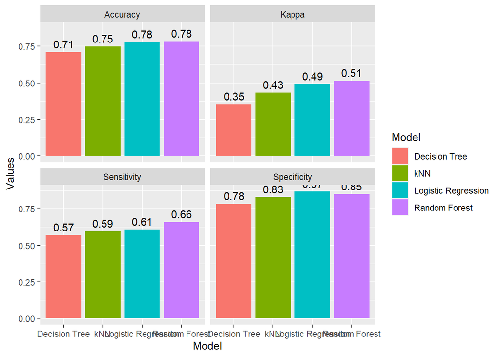

```r
# Visualising metrics across models
table_mdl_long <- gather(table_mdl, "Metric", "Values", 1:4)

ggplot(table_mdl_long, aes(Model, Values, fill = Model)) +
  geom_col() +
  geom_text(aes(label = round(Values, 2)), vjust = -.5) +
  facet_wrap(~Metric)
```

Modeling with random forest returns the highest overall values with accuracy, sensitivity and specificity at 78%, 66% and 85%, followed by logistic regression at 78%, 61% and 87%.